# cryptography course project

### **Bivariate and Multivariate Analysis**

Here will be comparing two or more variables to try and understand their comparison

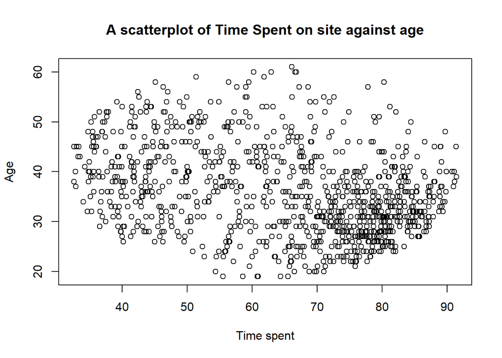

```r
plot((advert$`Daily Time Spent on Site`), (advert$Age),
     main = "A scatterplot of Time Spent on site against age",
     xlab = 'Time spent',
     ylab = 'Age')
```

We see there is concentration of Time spent daily on the site in relation to Age is concentrated on around 30s age bracket

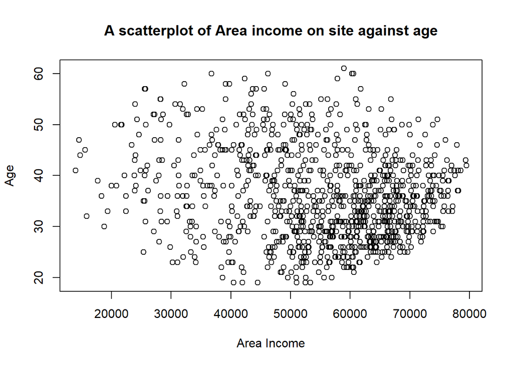

```r
plot((advert$`Area Income`), (advert$Age),
     main = "A scatterplot of Area income on site against age",
     xlab = 'Area Income',
     ylab = 'Age')
```

Most people concentrate around 50000 to 70000 area income for the majority age bracket

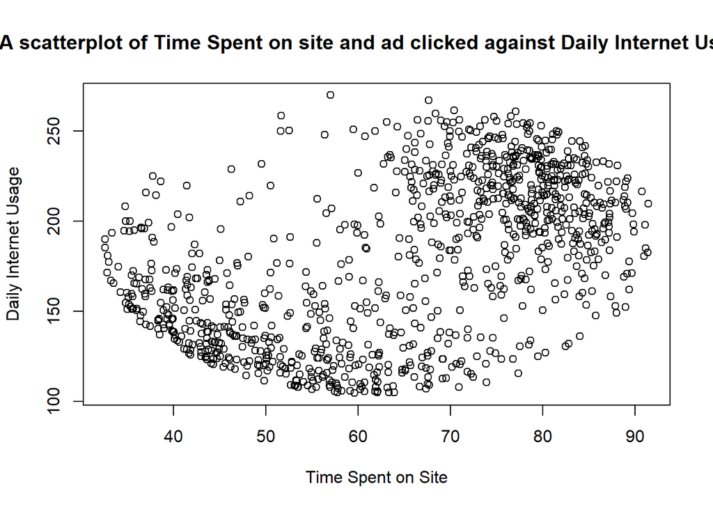

```r
plot((advert$`Daily Time Spent on Site`), (advert$`Daily Internet Usage`),
     main = "A scatterplot of Time Spent on site and ad clicked against Daily Internet Usage",
     xlab = 'Time Spent on Site',
     ylab = 'Daily Internet Usage')
```

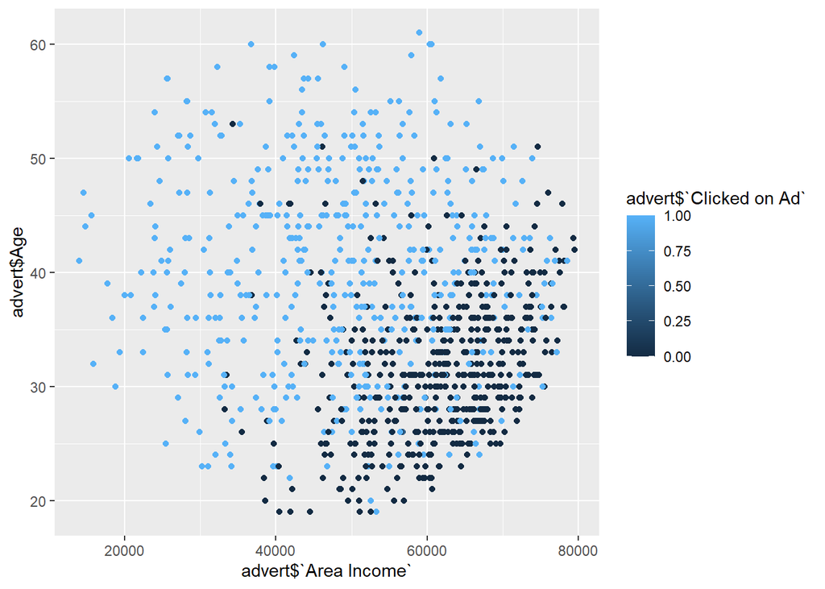

```r
ggplot(advert,aes(x=advert$`Area Income`,y=advert$Age,col=advert$`Clicked on Ad`))+geom_point(aes(color=advert$`Clicked on Ad`))
```

Let’s see click vs gender

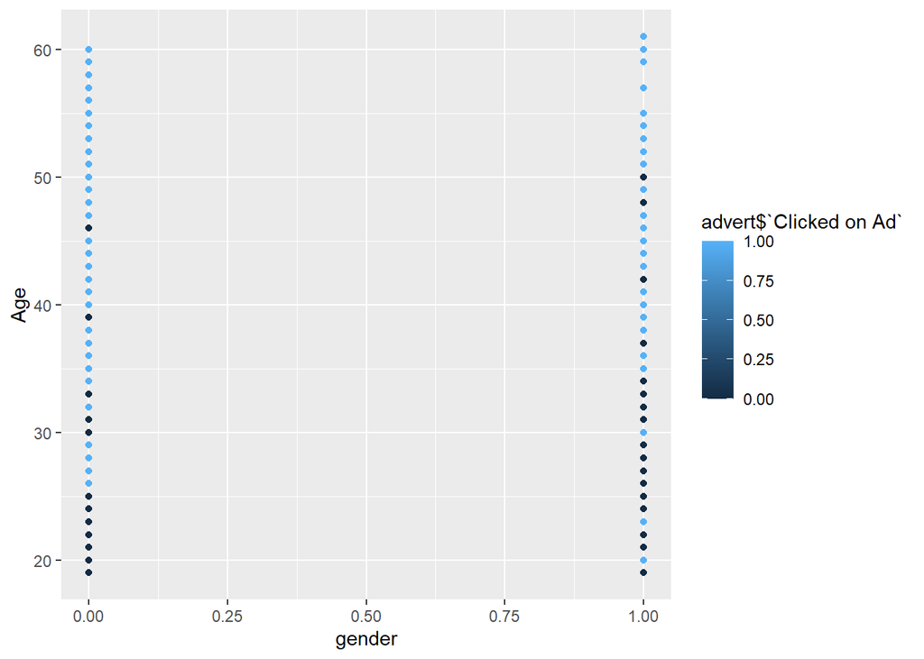

```r
ggplot(advert,aes(x=gender,y=Age,col=advert$`Clicked on Ad`))+geom_point(aes(color=advert$`Clicked on Ad`))
```

Let.s check for correlation

```r
library(corrplot)
numeric <- advert %>%
  select_if(is.numeric) %>%
  select("Daily Time Spent on Site", "Age", "Area Income", "Daily Internet Usage")
```

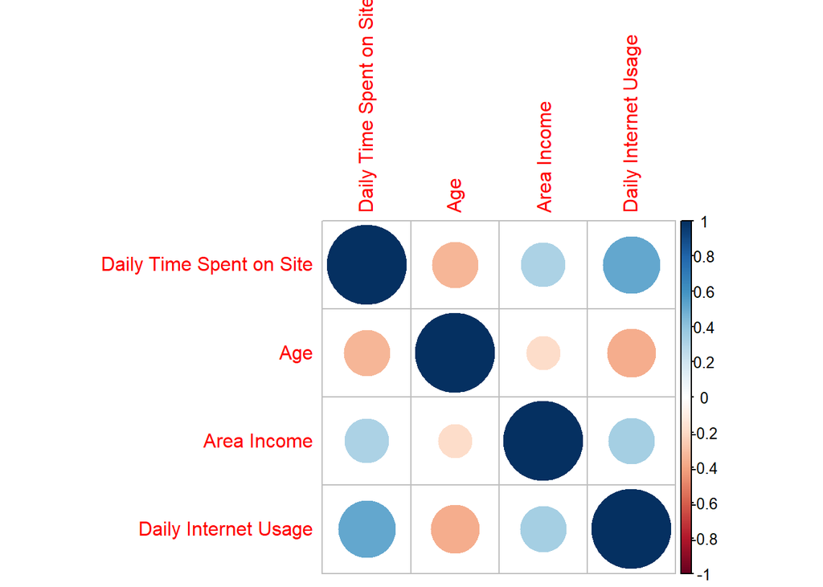

```r
corrplot(cor(numeric))
```

There a positive correlation observed inth plot between Daily internet usage vs time spent on internet daily.

There is also some correlation between area income and internet usage and time